# Cours 2 - Hands-on R

Mamadou Mbodj

2024-11-13

## Intro

Ce TP explore l’analyse de données avec R. Nous allons charger un jeu de données, effectuer des opérations de nettoyage, explorer la structure, manipuler et visualiser les données.

**Objectifs du TP**

- Charger et explorer les données
- Manipuler et transformer les données avec *dplyr*
- Visualiser les données avec *ggplot2*

## 1. Charger et Explorer les Données

Nous utiliserons un jeu de données d’exemple mtcars, intégré à R. Il contient des informations sur différents modèles de voitures, telles que la consommation d’essence, le nombre de cylindres, et la puissance.

```r
# Charger les données
data("mtcars")

# Aperçu des premières lignes
head(mtcars)
```

```
##                    mpg cyl disp  hp drat    wt  qsec vs am gear carb
## Mazda RX4         21.0   6  160 110 3.90 2.620 16.46  0  1    4    4
## Mazda RX4 Wag     21.0   6  160 110 3.90 2.875 17.02  0  1    4    4
## Datsun 710        22.8   4  108  93 3.85 2.320 18.61  1  1    4    1
## Hornet 4 Drive    21.4   6  258 110 3.08 3.215 19.44  1  0    3    1
## Hornet Sportabout 18.7   8  360 175 3.15 3.440 17.02  0  0    3    2
## Valiant           18.1   6  225 105 2.76 3.460 20.22  1  0    3    1
```

**Structure et résumé des données**

Explorons la structure des données et le résumé statistique de chaque variable pour mieux comprendre le jeu de données.

```r
# Structure des données
str(mtcars)
```

```
## 'data.frame':    32 obs. of  11 variables:
##  $ mpg : num  21 21 22.8 21.4 18.7 18.1 14.3 24.4 22.8 19.2 ...
##  $ cyl : num  6 6 4 6 8 6 8 4 4 6 ...
##  $ disp: num  160 160 108 258 360 ...
##  $ hp  : num  110 110 93 110 175 105 245 62 95 123 ...
##  $ drat: num  3.9 3.9 3.85 3.08 3.15 2.76 3.21 3.69 3.92 3.92 ...
##  $ wt  : num  2.62 2.88 2.32 3.21 3.44 ...
##  $ qsec: num  16.5 17 18.6 19.4 17 ...
##  $ vs  : num  0 0 1 1 0 1 0 1 1 1 ...
##  $ am  : num  1 1 1 0 0 0 0 0 0 0 ...
##  $ gear: num  4 4 4 3 3 3 3 4 4 4 ...
##  $ carb: num  4 4 1 1 2 1 4 2 2 4 ...
```

```r
# Résumé statistique
summary(mtcars)
```

```
##       mpg             cyl             disp             hp
##  Min.   :10.40   Min.   :4.000   Min.   : 71.1   Min.   : 52.0
##  1st Qu.:15.43   1st Qu.:4.000   1st Qu.:120.8   1st Qu.: 96.5
##  Median :19.20   Median :6.000   Median :196.3   Median :123.0
##  Mean   :20.09   Mean   :6.188   Mean   :230.7   Mean   :146.7
##  3rd Qu.:22.80   3rd Qu.:8.000   3rd Qu.:326.0   3rd Qu.:180.0
##  Max.   :33.90   Max.   :8.000   Max.   :472.0   Max.   :335.0
##       drat             wt             qsec             vs
##  Min.   :2.760   Min.   :1.513   Min.   :14.50   Min.   :0.0000
##  1st Qu.:3.080   1st Qu.:2.581   1st Qu.:16.89   1st Qu.:0.0000
##  Median :3.695   Median :3.325   Median :17.71   Median :0.0000
##  Mean   :3.597   Mean   :3.217   Mean   :17.85   Mean   :0.4375
##  3rd Qu.:3.920   3rd Qu.:3.610   3rd Qu.:18.90   3rd Qu.:1.0000
##  Max.   :4.930   Max.   :5.424   Max.   :22.90   Max.   :1.0000
##        am              gear            carb
##  Min.   :0.0000   Min.   :3.000   Min.   :1.000
##  1st Qu.:0.0000   1st Qu.:3.000   1st Qu.:2.000
##  Median :0.0000   Median :4.000   Median :2.000
##  Mean   :0.4062   Mean   :3.688   Mean   :2.812
##  3rd Qu.:1.0000   3rd Qu.:4.000   3rd Qu.:4.000
##  Max.   :1.0000   Max.   :5.000   Max.   :8.000
```

## 2. Manipulation des Données avec dplyr

Nous allons utiliser le package dplyr pour filtrer, sélectionner, créer des variables et résumer les données.

### 2.1 Filtrage et sélection de colonnes

Filtrons les voitures ayant plus de 6 cylindres et sélectionnons les colonnes *mpg* (miles per gallon) et *hp* (horsepower).

```r
# Filtrer les voitures avec plus de 6 cylindres et sélectionner des colonnes
filtered_data <- mtcars %>%
  filter(cyl > 6) %>%
  select(mpg, hp)

# Afficher le résultat
filtered_data
```

```
##                      mpg  hp
## Hornet Sportabout   18.7 175
## Duster 360          14.3 245
## Merc 450SE          16.4 180
## Merc 450SL          17.3 180
## Merc 450SLC         15.2 180
## Cadillac Fleetwood  10.4 205
## Lincoln Continental 10.4 215
## Chrysler Imperial   14.7 230
## Dodge Challenger    15.5 150
## AMC Javelin         15.2 150
## Camaro Z28          13.3 245
## Pontiac Firebird    19.2 175
## Ford Pantera L      15.8 264
## Maserati Bora       15.0 335
```

### 2.2 Création de nouvelles variables

Créons une nouvelle variable qui convertit *mpg* en litres par 100 km (lp100km). Cette conversion est donnée par *lp100km = 235.21 / mpg*.

```r
# Ajouter la colonne lp100km
mtcars <- mtcars %>%
  mutate(lp100km = 235.21 / mpg)

# Afficher les premières lignes
head(mtcars)
```

```
##                    mpg cyl disp  hp drat    wt  qsec vs am gear carb  lp100km
## Mazda RX4         21.0   6  160 110 3.90 2.620 16.46  0  1    4    4 11.20048
## Mazda RX4 Wag     21.0   6  160 110 3.90 2.875 17.02  0  1    4    4 11.20048
## Datsun 710        22.8   4  108  93 3.85 2.320 18.61  1  1    4    1 10.31623
## Hornet 4 Drive    21.4   6  258 110 3.08 3.215 19.44  1  0    3    1 10.99112
## Hornet Sportabout 18.7   8  360 175 3.15 3.440 17.02  0  0    3    2 12.57807
## Valiant           18.1   6  225 105 2.76 3.460 20.22  1  0    3    1 12.99503
```

### 2.3 Résumés et agrégations

Calculons la moyenne de la consommation (mpg) et de la puissance (hp) par nombre de cylindres.

```r
# Moyenne de mpg et hp par nombre de cylindres
summary_by_cyl <- mtcars %>%
  group_by(cyl) %>%
  summarise(mean_mpg = mean(mpg), mean_hp = mean(hp))

# Afficher le tableau récapitulatif
summary_by_cyl
```

```
## # A tibble: 3 × 3
##     cyl mean_mpg mean_hp
##   <dbl>    <dbl>   <dbl>
## 1     4     26.7    82.6
## 2     6     19.7   122.
## 3     8     15.1   209.
```

## 3. Visualisation des Données avec ggplot2

La visualisation est essentielle pour analyser les tendances et les relations entre les variables. Nous utiliserons *ggplot2* pour produire des graphiques basiques.

### 3.1 Diagramme de dispersion : Relation entre Puissance et Consommation

Nous allons créer un diagramme de dispersion pour visualiser la relation entre la puissance (*hp*) et la consommation (*mpg*).

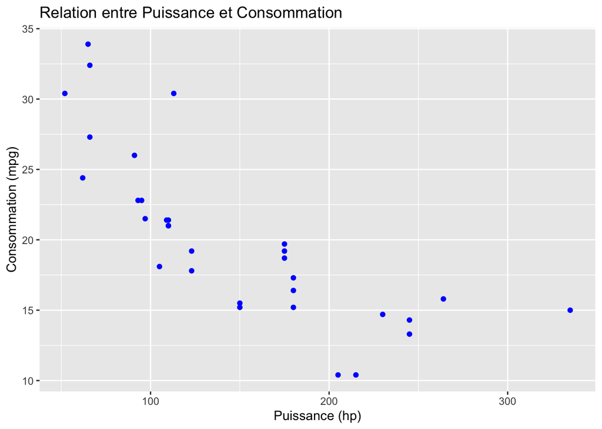

```r
# Diagramme de dispersion
ggplot(mtcars, aes(x = hp, y = mpg)) +
  geom_point(color = "blue") +
  labs(title = "Relation entre Puissance et Consommation",
       x = "Puissance (hp)",
       y = "Consommation (mpg)")
```

### 3.2 Histogramme de la Consommation

Visualisons la distribution de la consommation (*mpg*) avec un histogramme.

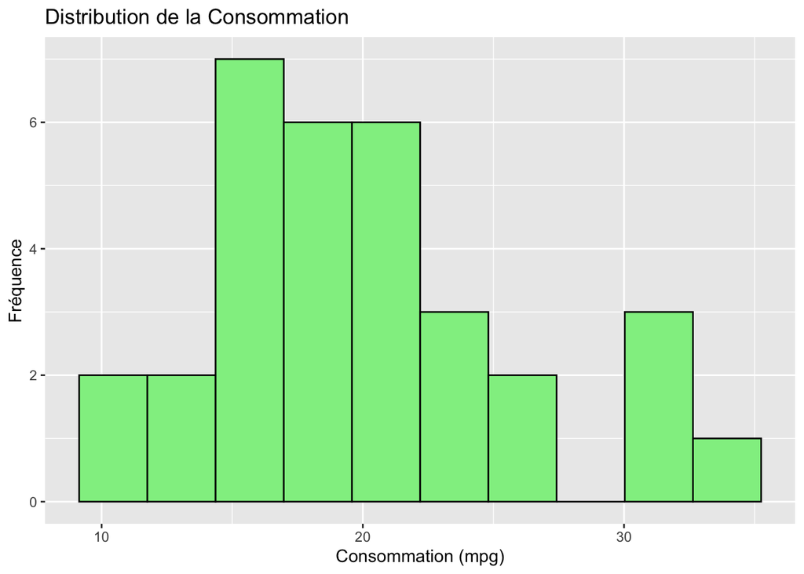

```r
# Histogramme de mpg
ggplot(mtcars, aes(x = mpg)) +
  geom_histogram(bins = 10, fill = "lightgreen", color = "black") +
  labs(title = "Distribution de la Consommation",
       x = "Consommation (mpg)",
       y = "Fréquence")
```